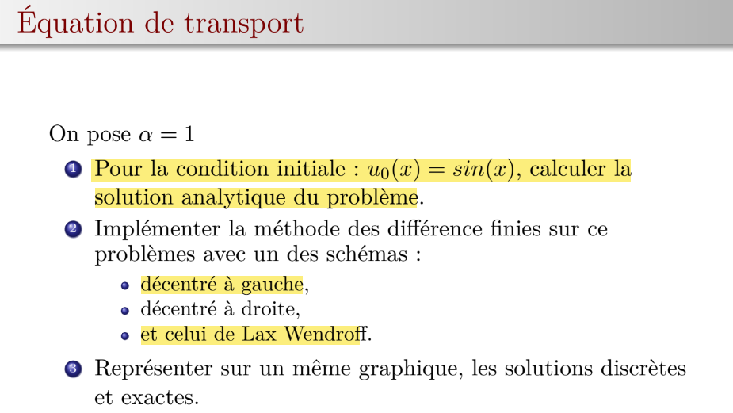

# Équation de Transport 1D:

# L'équation de transport avec vitesse $(\alpha)$ est donnée par :

# $\frac{\partial u}{\partial t} + \alpha \frac{\partial u}{\partial x} = 0 $

## Paramètres de l'exercice

On pose $\alpha = 1$.

1. Pour la condition initiale : $u_0(x) = \sin(x)$, calculer la solution analytique du problème.
2. Implémenter la méthode des différences finies sur ce problème avec les schémas :
   - décentré à gauche,
   - décentré à droite,
   - et celui de Lax-Wendroff.
3. Représenter sur un même graphique les solutions discrètes et exactes.

## Solution analytique

La solution analytique du problème avec la condition initiale $u_0(x) = \sin(x)$ est : $ u(x, t) = \sin(x - \alpha t)$ où $\alpha = 1$. Donc $u(x, t) = sin(x - t)$

## Implémentation des schémas de différences finies

### Schéma décentré à gauche

Le schéma décentré à gauche utilise une approximation de la dérivée spatiale en prenant le point courant et le point précédent : $\frac{\partial u}{\partial x} \approx \frac{u_i^n - u_{i-1}^n}{\Delta x}$

En substituant cette approximation dans l'équation de transport, nous obtenons : $\frac{u_i^{n+1} - u_i^n}{\Delta t} + \alpha \frac{u_i^n - u_{i-1}^n}{\Delta x} = 0$

En réarrangeant pour trouver $u_i^{n+1}$ : $u_i^{n+1} = u_i^n - \frac{\alpha \Delta t}{\Delta x} (u_i^n - u_{i-1}^n)$

### Schéma décentré à droite

Le schéma décentré à droite utilise une approximation de la dérivée spatiale en prenant le point courant et le point suivant : $\frac{\partial u}{\partial x} \approx \frac{u_{i+1}^n - u_i^n}{\Delta x}$

En substituant cette approximation dans l'équation de transport, nous obtenons : $\frac{u_i^{n+1} - u_i^n}{\Delta t} + \alpha \frac{u_{i+1}^n - u_i^n}{\Delta x} = 0$

En réarrangeant pour trouver $u_i^{n+1}$ : $ u_i^{n+1} = u_i^n - \frac{\alpha \Delta t}{\Delta x} (u_{i+1}^n - u_i^n)$

### Schéma de Lax-Wendroff

Le schéma de Lax-Wendroff utilise une combinaison de termes de différence centrée et de termes de différence temporelle pour améliorer la précision.

1. **Approximation de la dérivée temporelle :**

$\frac{\partial u}{\partial t} \approx \frac{u_i^{n+1} - u_i^n}{\Delta t}$

2. **Approximation de la dérivée spatiale centrée :** $\frac{\partial u}{\partial x} \approx \frac{u_{i+1}^n - u_{i-1}^n}{2 \Delta x}$
3. **Approximation du terme de diffusion :** $\frac{\partial^2 u}{\partial x^2} \approx \frac{u_{i+1}^n - 2u_i^n + u_{i-1}^n}{\Delta x^2}$

En substituant ces approximations dans l'équation de transport, nous obtenons : $\frac{u_i^{n+1} - u_i^n}{\Delta t} + \alpha \frac{u_{i+1}^n - u_{i-1}^n}{2 \Delta x} = \frac{\alpha^2 \Delta t}{2 \Delta x^2} (u_{i+1}^n - 2u_i^n + u_{i-1}^n)$

En réarrangeant pour trouver $u_i^{n+1}$ : $ u_i^{n+1} = u_i^n - \frac{\alpha \Delta t}{2 \Delta x} (u_{i+1}^n - u_{i-1}^n) + \frac{\alpha^2 \Delta t^2}{2 \Delta x^2} (u_{i+1}^n - 2u_i^n + u_{i-1}^n)$

### Explications

```
// Paramètres
L = 2 * %pi;          // Longueur du domaine
T = 2 * %pi;          // Temps total de simulation
nx = 100;             // Nombre de points spatiaux
nt = 100;             // Nombre de points temporels
dx = L / nx;          // Pas spatial
dt = T / nt;          // Pas temporel
alpha = 1;            // Vitesse de propagation

// Discrétisation spatiale et temporelle
x = linspace(0, L, nx);
t = linspace(0, T, nt);

// Condition initiale
u0 = sin(x);

// Schéma décentré à gauche
u_left = u0;
for n = 1:nt
    u_left(2:nx) = u_left(2:nx) - alpha * dt / dx * (u_left(2:nx) - u_left(1:nx-1));
    u_left(1) = u_left($); // Condition périodique
end

// Schéma décentré à droite
u_right = u0;
for n = 1:nt
    u_right(1:nx-1) = u_right(1:nx-1) - alpha * dt / dx * (u_right(2:nx) - u_right(1:nx-1));
    u_right($) = u_right(1); // Condition périodique
end

// Solution analytique
u_exact = sin(x - alpha * T);

// Tracer les solutions
clf(); // Effacer la figure précédente
plot(x, u_exact, 'k-', 'LineWidth', 3);  // Solution analytique
plot(x, u_left, 'r--', 'LineWidth', 2);  // Schéma décentré à gauche
plot(x, u_right, 'b-.', 'LineWidth', 2); // Schéma décentré à droite

// Légendes et titres
legend("Solution exacte", "Décentré à gauche", "Décentré à droite"); // Ajouter des légendes aux courbes
xlabel('x'); // Étiqueter l'axe des x
ylabel('u'); // Étiqueter l'axe des y
title("Solutions de l''équation de transport"); // Titre du graphique
xgrid(); // Activer la grille
```

[figure not shown]

```
// Paramètres
alpha = 1; // Coefficient de transport
L = 2 * %pi; // Longueur du domaine
Nx = 100; // Nombre de points spatiaux
x = linspace(0, L, Nx); // Grille spatiale
Delta_x = x(2) - x(1); // Pas spatial
Delta_t = 0.01; // Pas temporel
T = 2; // Temps total de simulation
Nt = round(T / Delta_t); // Nombre de pas temporels

// Condition initiale
u_exact = sin(x); // Solution exacte à t=0
u_left = u_exact; // Solution pour le schéma décentré à gauche
u_right = u_exact; // Solution pour le schéma décentré à droite
u_lax_wendroff = u_exact; // Solution pour le schéma de Lax-Wendroff

// Boucle temporelle
for n = 1:Nt
    // Schéma décentré à gauche
    for i = 2:Nx
        u_left(i) = u_left(i) - (alpha * Delta_t / Delta_x) * (u_left(i) - u_left(i-1));
    end

    // Schéma décentré à droite
    for i = 1:Nx-1
        u_right(i) = u_right(i) - (alpha * Delta_t / Delta_x) * (u_right(i+1) - u_right(i));
    end

    // Schéma de Lax-Wendroff
    for i = 2:Nx-1
        u_lax_wendroff(i) = u_lax_wendroff(i) - (alpha * Delta_t / (2 * Delta_x)) * (u_lax_wendroff(i+1) - u_lax_wendroff(i-1)) + ...
                             (alpha^2 * Delta_t^2 / (2 * Delta_x^2)) * (u_lax_wendroff(i+1) - 2 * u_lax_wendroff(i) + u_lax_wendroff(i-1));
    end

    // Conditions aux limites (périodiques)
    u_left(1) = u_left(Nx);
    u_right(Nx) = u_right(1);
    u_lax_wendroff(1) = u_lax_wendroff(Nx);
    u_lax_wendroff(Nx) = u_lax_wendroff(2); // Pour maintenir la condition périodique
end

// Solution exacte à t=T
u_exact_final = sin(x - alpha * T);

// Tracé des résultats
clf; // Effacer la figure précédente
plot(x, u_exact_final, 'r', 'LineWidth', 2); // Solution exacte
plot(x, u_left, 'b--', 'LineWidth', 1.5); // Schéma décentré à gauche
plot(x, u_right, 'g--', 'LineWidth', 1.5); // Schéma décentré à droite
plot(x, u_lax_wendroff, 'm--', 'LineWidth', 1.5); // Schéma de Lax-Wendroff
xlabel('x');
ylabel('u(x, t)');
title('Solutions de l''équation de transport');
legend('Solution exacte', 'Schéma décentré à gauche', 'Schéma décentré à droite', 'Schéma de Lax-Wendroff');
xtitle('Solutions de l''équation de transport');
```

[figure not shown]

```
// Paramètres
L = 2 * %pi;
T = 2 * %pi;
nx = 100;
nt = 100;
dx = L / nx;
dt = T / nt;
alpha = 1;

// Discrétisation spatiale et temporelle
x = linspace(0, L, nx);
t = linspace(0, T, nt);

// Condition initiale
u0 = sin(x);

// Schéma décentré à gauche
u_left = u0;
for n = 1:nt
    u_left(2:nx) = u_left(2:nx) - alpha * dt / dx * (u_left(2:nx) - u_left(1:nx-1));
    u_left(1) = u_left($);
end

// Schéma décentré à droite
u_right = u0;
for n = 1:nt
    u_right(1:nx-1) = u_right(1:nx-1) - alpha * dt / dx * (u_right(2:nx) - u_right(1:nx-1));
    u_right($) = u_right(1);
end

// Schéma de Lax-Wendroff
u_lax = u0;
for n = 1:nt
    u_lax(2:nx-1) = u_lax(2:nx-1) - 0.5 * alpha * dt / dx * (u_lax(3:nx) - u_lax(1:nx-2)) ...
                   + 0.5 * (alpha * dt / dx)^2 * (u_lax(3:nx) - 2 * u_lax(2:nx-1) + u_lax(1:nx-2));
    u_lax(1) = u_lax($);
    u_lax($) = u_lax(1);
end

// Solution analytique
u_exact = sin(x - alpha * T);

// Tracer les solutions
clf();
plot(x, u_exact, 'k-', 'LineWidth', 3);
plot(x, u_left, 'r--', 'LineWidth', 2);
plot(x, u_right, 'b-.', 'LineWidth', 2);
plot(x, u_lax, 'g:', 'LineWidth', 2);
legend("Solution exacte", "Décentré à gauche", "Décentré à droite", "Lax-Wendroff");
xlabel('x');
ylabel('u');
title("Solutions de l''équation de transport");
xgrid();
```

[figure not shown]